# Appendix I - User Characteristics and Preferences

```python
#import libraries
import pandas as pd
import numpy as np
import matplotlib.pyplot as plt
from matplotlib.pyplot import MultipleLocator
import seaborn as sns
import datetime
from datetime import date
```

## Data-preprocessing

```python
#import data
creator_demo = pd.read_csv('./csv_data/creator_demographics.csv')
creator_stats = pd.read_csv('./csv_data/creator_stats.csv')
impression = pd.read_csv('./csv_data/impression_data.csv')
mlog_demo = pd.read_csv('./csv_data/mlog_demographics.csv')
mlog_stats = pd.read_csv('./csv_data/mlog_stats.csv')
user_demo = pd.read_csv('./csv_data/user_demographics.csv')
```

```python
#check data info
creator_demo.info()
creator_demo.head()
```

```
<class 'pandas.core.frame.DataFrame'>
RangeIndex: 90534 entries, 0 to 90533
Data columns (total 7 columns):
 #   Column              Non-Null Count  Dtype
---  ------              --------------  -----
 0   creatorId           90534 non-null  object
 1   gender              52540 non-null  object
 2   registeredMonthCnt  90534 non-null  int64
 3   follows             90534 non-null  int64
 4   followeds           90534 non-null  int64
 5   creatorType         90534 non-null  int64
 6   level               90534 non-null  int64
dtypes: int64(5), object(2)
memory usage: 4.8+ MB
```

|  | creatorId | gender | registeredMonthCnt | follows | followeds | creatorType | level |
| --- | --- | --- | --- | --- | --- | --- | --- |
| 0 | JCJCKCPCOCNCMCHC | male | 54 | 29 | 28 | 0 | 8 |
| 1 | NCNCICLCJCHCLCNCPC | NaN | 35 | 17 | 2 | 0 | 7 |
| 2 | NCJCKCICNCICICGCMC | NaN | 36 | 12 | 29 | 0 | 7 |
| 3 | NCGCLCMCJCMCJCLCHC | NaN | 36 | 127 | 18 | 0 | 9 |
| 4 | ICMCHCPCHCHCLCGCOC | NaN | 26 | 17 | 3 | 0 | 8 |

```python
#check data info
creator_stats.info()
creator_stats.head()
```

```
<class 'pandas.core.frame.DataFrame'>
RangeIndex: 2572512 entries, 0 to 2572511
Data columns (total 3 columns):
 #   Column           Dtype
---  ------           -----
 0   creatorId        object
 1   dt               int64
 2   PushlishMlogCnt  int64
dtypes: int64(2), object(1)
memory usage: 58.9+ MB
```

|  | creatorId | dt | PushlishMlogCnt |
| --- | --- | --- | --- |
| 0 | PCGCHCGCKCHCNCPCMCHC | 8 | 0 |
| 1 | MCGCHCJCMCICMCKCHC | 8 | 0 |
| 2 | LCPCJCNCHCLCMCGCMC | 8 | 0 |
| 3 | LCLCMCOCICMCOCICHC | 8 | 0 |
| 4 | PCKCNCGCNCOCLCKCHCMC | 8 | 0 |

```python
#check data info
impression.info()
impression.head()
```

```
<class 'pandas.core.frame.DataFrame'>
RangeIndex: 57750395 entries, 0 to 57750394
Data columns (total 13 columns):
 #   Column                  Dtype
---  ------                  -----
 0   detailMlogInfoList      object
 1   dt                      int64
 2   impressPosition         int64
 3   impressTime             int64
 4   isClick                 int64
 5   isComment               int64
 6   isIntoPersonalHomepage  int64
 7   isShare                 int64
 8   isViewComment           int64
 9   isLike                  int64
 10  mlogId                  object
 11  mlogViewTime            float64
 12  userId                  object
dtypes: float64(1), int64(9), object(3)
memory usage: 5.6+ GB
```

|  | detailMlogInfoList | dt | impressPosition | impressTime | isClick | isComment | isIntoPersonalHomepage | isShare | isViewComment | isLike | mlogId | mlogViewTime | userId |
| --- | --- | --- | --- | --- | --- | --- | --- | --- | --- | --- | --- | --- | --- |
| 0 | NaN | 29 | 1 | 1574980776000 | 0 | 0 | 0 | 0 | 0 | 0 | NCLCPCJCOCGCJC | NaN | PCNCGCGCLCOCOCOCJCGC |
| 1 | NaN | 25 | 6 | 1574684613000 | 0 | 0 | 0 | 0 | 0 | 0 | KCNCOCNCMCOCMC | NaN | PCNCGCGCLCOCOCOCJCGC |
| 2 | [{'isZan': '0', 'isComment': '0', 'mlogId': 'K... | 25 | 1 | 1574684241000 | 1 | 0 | 0 | 0 | 0 | 0 | NCHCGCICLCPCGC | 2.98 | PCNCGCGCLCOCOCOCJCGC |
| 3 | NaN | 15 | 3 | 1573767973000 | 0 | 0 | 0 | 0 | 0 | 0 | PCNCNCPCICLCGC | NaN | PCNCGCGCLCOCOCOCJCGC |
| 4 | NaN | 15 | 2 | 1573767973000 | 0 | 0 | 0 | 0 | 0 | 0 | NCHCICPCOCLCOC | NaN | PCNCGCGCLCOCOCOCJCGC |

```python
#check data info
mlog_demo.info()
mlog_demo.head()
```

```
<class 'pandas.core.frame.DataFrame'>
RangeIndex: 252955 entries, 0 to 252954
Data columns (total 8 columns):
 #   Column       Non-Null Count   Dtype
---  ------       --------------   -----
 0   mlogId       252955 non-null  object
 1   songId       252955 non-null  object
 2   artistId     252955 non-null  object
 3   creatorId    252955 non-null  object
 4   publishTime  252955 non-null  int64
 5   type         252955 non-null  int64
 6   contentId    181671 non-null  object
 7   talkId       252955 non-null  int64
dtypes: int64(3), object(5)
memory usage: 15.4+ MB
```

|  | mlogId | songId | artistId | creatorId | publishTime | type | contentId | talkId |
| --- | --- | --- | --- | --- | --- | --- | --- | --- |
| 0 | NCGCJCNCPCPCOC | PCNCGCLCGCLCICHCLCIC | NCMCNCHCHCMCMCJC | LCHCHCICPCHCHCICKC | 35 | 1 | 5000,5006,5036 | 13003 |
| 1 | MCLCOCOCKCOCIC | MCGCKCGCPCPCGCHC | ICKCOCJCIC | MCICJCPCOCOCLCKCPC | 105 | 1 | NaN | -1 |
| 2 | PCMCMCICNCICOC | PCNCJCJCGCJCOCNCPCPC | PCMCOCLCICOCPCOC | PCNCLCKCGCMCPCOCOCMC | 140 | 1 | 5004,5028,5152 | 2005 |
| 3 | KCOCHCPCPCHCPC | AFBHAHLH | AFBHAHLH | LCJCGCJCMCICHCLCHC | 25 | 2 | 5001,5010,5054 | 1307098 |
| 4 | NCGCHCICPCPCKC | LCOCNCMCICGCMCKCIC | PCMCNCPCJCHC | PCKCICMCGCGCICMCKCPC | 35 | 1 | 5001,5012,5076 | 6005 |

```python
#check data info
mlog_stats.info()
mlog_stats.head()
```

```
<class 'pandas.core.frame.DataFrame'>
RangeIndex: 4191677 entries, 0 to 4191676
Data columns (total 10 columns):
 #   Column                         Dtype
---  ------                         -----
 0   mlogId                         object
 1   dt                             int64
 2   userImprssionCount             int64
 3   userClickCount                 int64
 4   userLikeCount                  int64
 5   userCommentCount               int64
 6   userShareCount                 int64
 7   userViewCommentCount           int64
 8   userIntoPersonalHomepageCount  int64
 9   userFollowCreatorCount         int64
dtypes: int64(9), object(1)
memory usage: 319.8+ MB
```

|  | mlogId | dt | userImprssionCount | userClickCount | userLikeCount | userCommentCount | userShareCount | userViewCommentCount | userIntoPersonalHomepageCount | userFollowCreatorCount |
| --- | --- | --- | --- | --- | --- | --- | --- | --- | --- | --- |
| 0 | KCNCLCICKCHCLC | 26 | 7907 | 71 | 1 | 0 | 0 | 3 | 0 | 0 |
| 1 | KCOCNCHCGCHCIC | 30 | 1 | 0 | 0 | 0 | 0 | 0 | 0 | 0 |
| 2 | NCKCMCKCNCNCOC | 11 | 169 | 15 | 1 | 0 | 0 | 0 | 0 | 0 |
| 3 | NCJCOCJCLCGCJC | 14 | 324 | 27 | 2 | 1 | 0 | 7 | 0 | 0 |
| 4 | NCGCOCKCOCOCKC | 17 | 154 | 10 | 2 | 0 | 0 | 4 | 0 | 0 |

```python
#check data info
user_demo.info()
user_demo.head()
```

```
<class 'pandas.core.frame.DataFrame'>
RangeIndex: 2085533 entries, 0 to 2085532
Data columns (total 7 columns):
 #   Column              Dtype
---  ------              -----
 0   userId              object
 1   province            object
 2   age                 float64
 3   gender              object
 4   registeredMonthCnt  float64
 5   followCnt           float64
 6   level               float64
dtypes: float64(4), object(3)
memory usage: 111.4+ MB
```

|  | userId | province | age | gender | registeredMonthCnt | followCnt | level |
| --- | --- | --- | --- | --- | --- | --- | --- |
| 0 | MCPCHCMCHCIC | an hui | 21.0 | male | 80.0 | 44.0 | 9.0 |
| 1 | NCOCKCPCMCGCGC | tian jin | 23.0 | male | 76.0 | 59.0 | 8.0 |
| 2 | PCKCOCMCGCGCHCKC | shang hai | NaN | NaN | 69.0 | 21.0 | 7.0 |
| 3 | MCICHCKCKCGCMCIC | bei jing | NaN | NaN | 66.0 | 38.0 | 10.0 |
| 4 | NCJCHCPCNCICNCNC | hu bei | 20.0 | male | 57.0 | 29.0 | 8.0 |

```python
user_demo.describe()
```

|  | age | registeredMonthCnt | followCnt | level |
| --- | --- | --- | --- | --- |
| count | 1.344042e+06 | 2.085124e+06 | 2.085124e+06 | 2.085124e+06 |
| mean | 2.150780e+01 | 2.379156e+01 | 1.063215e+01 | 5.669522e+00 |
| std | 3.756435e+00 | 1.513285e+01 | 2.615071e+01 | 2.169045e+00 |
| min | 1.100000e+01 | 0.000000e+00 | 0.000000e+00 | 0.000000e+00 |
| 25% | 1.900000e+01 | 1.100000e+01 | 3.000000e+00 | 5.000000e+00 |
| 50% | 2.200000e+01 | 2.300000e+01 | 5.000000e+00 | 6.000000e+00 |
| 75% | 2.400000e+01 | 3.500000e+01 | 1.000000e+01 | 7.000000e+00 |
| max | 5.700000e+01 | 6.080000e+02 | 2.465000e+03 | 1.000000e+01 |

We can see that there is an outlier in the registered month data which is 608. The NCM was first launched in 2013 which is about 6 years before 2019. The maximum registered month in our dataset is 608 which is about 50 years. There's no way a user has been registered for a longer period than the period the company has been existed. Therefore, we will exclude these outliers from the following analysis, i.e., users with more than 80 months registered, as the longest registered duration should only be 80 months.

```python
user_demo = user_demo.loc[user_demo['registeredMonthCnt']<=80]
```

## 1. User Engagement and Characteristics

### 1.1 Usage Scenarios

```python
# converting 'impressTime' from epoch to datetime
impression['impressTime'] = [datetime.datetime.fromtimestamp(x/1000) for x in impression['impressTime']]
```

```python
impression.head()
```

|  | detailMlogInfoList | dt | impressPosition | impressTime | isClick | isComment | isIntoPersonalHomepage | isShare | isViewComment | isLike | mlogId | mlogViewTime | userId |
| --- | --- | --- | --- | --- | --- | --- | --- | --- | --- | --- | --- | --- | --- |
| 0 | NaN | 29 | 1 | 2019-11-29 06:39:36 | 0 | 0 | 0 | 0 | 0 | 0 | NCLCPCJCOCGCJC | NaN | PCNCGCGCLCOCOCOCJCGC |
| 1 | NaN | 25 | 6 | 2019-11-25 20:23:33 | 0 | 0 | 0 | 0 | 0 | 0 | KCNCOCNCMCOCMC | NaN | PCNCGCGCLCOCOCOCJCGC |
| 2 | [{'isZan': '0', 'isComment': '0', 'mlogId': 'K... | 25 | 1 | 2019-11-25 20:17:21 | 1 | 0 | 0 | 0 | 0 | 0 | NCHCGCICLCPCGC | 2.98 | PCNCGCGCLCOCOCOCJCGC |
| 3 | NaN | 15 | 3 | 2019-11-15 05:46:13 | 0 | 0 | 0 | 0 | 0 | 0 | PCNCNCPCICLCGC | NaN | PCNCGCGCLCOCOCOCJCGC |
| 4 | NaN | 15 | 2 | 2019-11-15 05:46:13 | 0 | 0 | 0 | 0 | 0 | 0 | NCHCICPCOCLCOC | NaN | PCNCGCGCLCOCOCOCJCGC |

```python
print('Unique number of impressions = ',impression.impressTime.nunique())
print('Unique number of cards = ',impression.mlogId.nunique())
print('Unique number of users = ',impression.userId.nunique())
```

```
Unique number of impressions =  2459357
Unique number of cards =  211066
Unique number of users =  2085602
```

```python
#get date
impression['date'] = [x.date() for x in impression['impressTime']]
```

```python
#create a dataframe to show daily total impression
daily_impr = pd.DataFrame(impression['mlogId'].groupby(impression['date']).count())
```

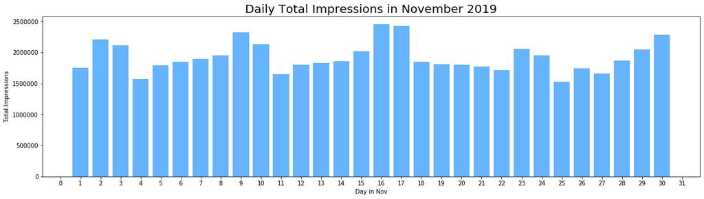

```python
#draw daily total impression
plt.figure(figsize=(20,5))

plt.title('Daily Total Impressions in November 2019',size=20)
plt.bar([x.day for x in daily_impr.index],daily_impr['mlogId'],color = '#66b3ff')
plt.xlabel('Day in Nov')
plt.ylabel('Total Impressions')

x_major_locator=MultipleLocator(1)
ax=plt.gca()
ax.xaxis.set_major_locator(x_major_locator)

#plt.grid(True)
#ax.xaxis.grid(color='black',linestyle='--',linewidth=1,alpha=1)

plt.show()
```

The above figure shows the number of impressions per day across the month, we observe a cyclical pattern with an increased level of activity at the weekends.

```python
#get hour
impression['hour'] = [x.hour for x in impression['impressTime']]
```

```python
#create a dataframe to show impressions per hour of the day
hourly_impr = pd.DataFrame(impression['mlogId'].groupby(impression['hour']).count())
```

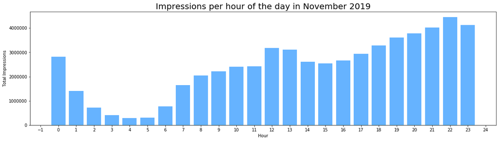

```python
#draw impressions per hour of the day
plt.figure(figsize=(20,5))

plt.title('Impressions per hour of the day in November 2019',size=20)
plt.bar(hourly_impr.index,hourly_impr['mlogId'],color = '#66b3ff')
plt.xlabel('Hour')
plt.ylabel('Total Impressions')

x_major_locator=MultipleLocator(1)
ax=plt.gca()
ax.xaxis.set_major_locator(x_major_locator)

#plt.grid(True)
#ax.xaxis.grid(color='black',linestyle='--',linewidth=1,alpha=1)

plt.show()
```

Closer inspection of the data also reveals a daily cyclical patten, shown in the above figure, where an increase in the impressions during lunch time and in the evening after work can be observed.

From this we can infer the predominant use case for the application is to unwind and decompress outside of working hours.

### 1.2 User Activity Intensity

```python
user_demo.head()
```

|  | userId | province | age | gender | registeredMonthCnt | followCnt | level |
| --- | --- | --- | --- | --- | --- | --- | --- |
| 0 | MCPCHCMCHCIC | an hui | 21.0 | male | 80.0 | 44.0 | 9.0 |
| 1 | NCOCKCPCMCGCGC | tian jin | 23.0 | male | 76.0 | 59.0 | 8.0 |
| 2 | PCKCOCMCGCGCHCKC | shang hai | NaN | NaN | 69.0 | 21.0 | 7.0 |
| 3 | MCICHCKCKCGCMCIC | bei jing | NaN | NaN | 66.0 | 38.0 | 10.0 |
| 4 | NCJCHCPCNCICNCNC | hu bei | 20.0 | male | 57.0 | 29.0 | 8.0 |

In the dataset, NCM provides us with a column 'level' which shows the activity intensity of the user ranging from 0 to 10. The activity intensity level is a combination of a user’s app time and frequency of interactions with app; the smaller this number is, the less active the user is. (Zhang et al.(2020)).

We will first take a look at the 'level' column.

```python
level = pd.DataFrame(user_demo['userId'].groupby(user_demo['level']).count())
```

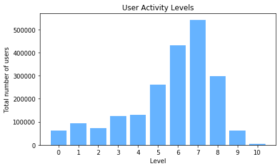

```python
#draw impressions per hour of the day
plt.figure(figsize=(7,4))

plt.title('User Activity Levels',size=12)
plt.bar(level.index,level['userId'],color = '#66b3ff')
plt.xlabel('Level')
plt.ylabel('Total number of users')

x_major_locator=MultipleLocator(1)
ax=plt.gca()
ax.xaxis.set_major_locator(x_major_locator)

#plt.grid(True)
#ax.xaxis.grid(color='black',linestyle='--',linewidth=1,alpha=1)

plt.show()
```

```python
#Join table impression and user_demo
impression_user = impression.merge(user_demo, how = 'inner', on = 'userId')
```

```python
level_behavior = impression_user[['isClick','isComment', 'isIntoPersonalHomepage', 'isShare', 'isViewComment','isLike']].groupby(impression_user['level']).mean()
level_behavior
```

| level | isClick | isComment | isIntoPersonalHomepage | isShare | isViewComment | isLike |
| --- | --- | --- | --- | --- | --- | --- |
| 0.0 | 0.040625 | 0.000091 | 0.000809 | 0.001018 | 0.003536 | 0.002626 |
| 1.0 | 0.046355 | 0.000125 | 0.000815 | 0.000248 | 0.004576 | 0.003093 |
| 2.0 | 0.046843 | 0.000099 | 0.000690 | 0.000250 | 0.004720 | 0.002918 |
| 3.0 | 0.052433 | 0.000118 | 0.000757 | 0.000370 | 0.005479 | 0.003107 |
| 4.0 | 0.049670 | 0.000120 | 0.000654 | 0.000301 | 0.005361 | 0.002731 |
| 5.0 | 0.053189 | 0.000137 | 0.000635 | 0.000339 | 0.006078 | 0.003015 |
| 6.0 | 0.052640 | 0.000143 | 0.000603 | 0.000326 | 0.007294 | 0.002772 |
| 7.0 | 0.049723 | 0.000140 | 0.000550 | 0.000323 | 0.007918 | 0.002292 |
| 8.0 | 0.047298 | 0.000132 | 0.000516 | 0.000364 | 0.008653 | 0.001938 |
| 9.0 | 0.044823 | 0.000409 | 0.000549 | 0.000299 | 0.009624 | 0.001631 |
| 10.0 | 0.036966 | 0.000161 | 0.000635 | 0.000376 | 0.009013 | 0.000997 |

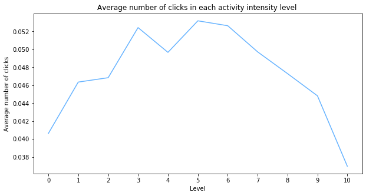

```python
#draw average number of clicks in each activity intensity level
plt.figure(figsize=(10,5))

plt.title('Average number of clicks in each activity intensity level ',size=12)
plt.plot(level_behavior.index,level_behavior['isClick'],color = '#66b3ff')
plt.xlabel('Level')
plt.ylabel('Average number of clicks')

x_major_locator=MultipleLocator(1)
ax=plt.gca()
ax.xaxis.set_major_locator(x_major_locator)

#plt.grid(True)
#ax.xaxis.grid(color='black',linestyle='--',linewidth=1,alpha=1)

plt.show()
```

```python
#top 10 active user
top10_user = pd.DataFrame(impression_user['isClick'].groupby(impression_user['userId']).sum().sort_values(ascending=False).head(10))
top10_user = top10_user.reset_index(drop=False)
top10_user = top10_user.merge(user_demo[user_demo['userId'].isin(list(top10_user['userId']))][['userId','level']].reset_index(drop=True),how = 'inner', on = 'userId')
```

```python
top10_user
```

|  | userId | isClick | level |
| --- | --- | --- | --- |
| 0 | PCKCLCMCGCOCMCKCJCLC | 2079 | 5.0 |
| 1 | ICOCJCKCKCOCHCHCIC | 1813 | 9.0 |
| 2 | PCHCPCKCICICKCNCLCNC | 1300 | 6.0 |
| 3 | PCLCPCHCLCLCKCJCGCOC | 1120 | 5.0 |
| 4 | PCHCICOCKCHCNCKCLCGC | 1115 | 3.0 |
| 5 | PCMCGCJCMCPCNCKCKCMC | 1100 | 8.0 |
| 6 | NCJCJCLCNCLCICKCNC | 1031 | 9.0 |
| 7 | MCOCMCHCMCMCLCNCICIC | 989 | 1.0 |
| 8 | PCNCICGCLCKCOCJCKCLC | 973 | 3.0 |
| 9 | MCKCJCMCGCKCMCKCOC | 968 | 8.0 |

We can clearly see that a higher activity intensity level doesn't guarantee an actual active behavior, as the average number of clicks is decreasing from level 5 to 10 and reaching the lowest value at level 10. And when we look at the Top 10 most active users, their activity intensity level ranges from 1 to 9. Therefore, we don't think the activity intensity level in the dataset is a good indicator for classifying active and inactive users, instead, we assign an new activity level marker to each user based on their clicks in November 2019. We use the percentage of cards a user clicked on from the total number of impressions they were exposed to during the month, also known as the click-through rate (CTR), as a proxy of the click probability on recommended cards.

```python
#calculate click probablity
click_prob = pd.DataFrame(impression_user['isClick'].groupby(impression_user['userId']).sum()).reset_index(drop=False).merge(pd.DataFrame(impression_user['mlogId'].groupby(impression_user['userId']).count()).reset_index(drop=False),how='inner',on='userId')
click_prob['click_perc'] = click_prob['isClick']/click_prob['mlogId']
click_prob.columns = ['userId', 'TotalClick', 'TotalMlog', 'click_perc']
```

```python
mean_click = click_prob['click_perc'].mean()
print('The average click probability is',mean_click)
```

```
The average click probability is 0.023380664006795563
```

We define that users with less than average click probability (around 2.338%) are classified as 'inactive'.  
We will add a binary column to indicate the activity of a user with 1 for active and 0 for inactive.

```python
#get activity for each user with 1 for active and 0 for inactive
activity = []
for p in click_prob['click_perc']:
    if p >= mean_click:
        activity.append(1)
    else:
        activity.append(0)
click_prob['activity'] = activity
```

```python
#create active user table and inactive user table
active_user = click_prob.loc[click_prob['click_perc'] >= mean_click].reset_index(drop=True)
inactive_user = click_prob.loc[click_prob['click_perc'] < mean_click].reset_index(drop=True)
```

```python
print('The percentage of active user is',round(len(active_user)/len(click_prob),4))
print('The percentage of inactive user is',round(len(inactive_user)/len(click_prob),4))
```

```
The percentage of active user is 0.1916
The percentage of inactive user is 0.8084
```

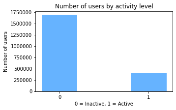

```python
#draw number of users by activity level
plt.figure(figsize=(5,3))

plt.title('Number of users by activity level',size=12)
plt.bar(click_prob.groupby('activity').count().index,click_prob.groupby('activity').count()['userId'],width=0.4,color = '#66b3ff')
plt.xlabel('0 = Inactive, 1 = Active')
plt.ylabel('Number of users')

x_major_locator=MultipleLocator(1)
ax=plt.gca()
ax.xaxis.set_major_locator(x_major_locator)

#plt.grid(True)
#ax.xaxis.grid(color='black',linestyle='--',linewidth=1,alpha=1)

plt.show()
```

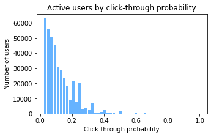

```python
#histogram of active users by click-through probablity
plt.figure(figsize=(5,3))
plt.title('Active users by click-through probability',size=12)
plt.hist(active_user['click_perc'],bins=50,rwidth=0.8,color = '#66b3ff')
plt.xlabel('Click-through probability')
plt.ylabel('Number of users')
```

```python
print('The percentage of active users with a click probability greater than 20% is', round(len(active_user.loc[active_user['click_perc']>= 0.2])/len(active_user),4))
```

```
The percentage of active users with a click probability greater than 20% is 0.1875
```

Having developed an understanding of active and inactive users, we then try to better understand the impact of some user features on their level of engagement.

### 1.3 User demographics

We have some user demographic information, including province, age and gender. In addition, user tenure(measured by the registered months) and the number of people a user has followed till December 1st are also provided. We then delve into the analysis of how active users differ from the inactive ones in terms of these user features.

```python
#drop rows with null value
user_demo_new = user_demo.dropna()
```

```python
#merge user_demo with click_prob
user_demo_prob = user_demo_new.merge(click_prob,how='inner',on='userId')
```

```python
#drop rows where gender is 'unknown'
user_demo_prob = user_demo_prob.loc[user_demo_prob['gender']!='unknown']
```

```python
user_demo_prob.head()
```

|  | userId | province | age | gender | registeredMonthCnt | followCnt | level | TotalClick | TotalMlog | click_perc | activity |
| --- | --- | --- | --- | --- | --- | --- | --- | --- | --- | --- | --- |
| 0 | MCPCHCMCHCIC | an hui | 21.0 | male | 80.0 | 44.0 | 9.0 | 1 | 118 | 0.008475 | 0 |
| 1 | NCOCKCPCMCGCGC | tian jin | 23.0 | male | 76.0 | 59.0 | 8.0 | 4 | 167 | 0.023952 | 1 |
| 2 | NCJCHCPCNCICNCNC | hu bei | 20.0 | male | 57.0 | 29.0 | 8.0 | 0 | 4 | 0.000000 | 0 |
| 3 | NCGCHCGCKCNCHCJC | shang hai | 26.0 | male | 63.0 | 10.0 | 6.0 | 0 | 3 | 0.000000 | 0 |
| 4 | KCKCGCMCGCHCHCLC | fu jian | 20.0 | male | 61.0 | 11.0 | 9.0 | 1 | 53 | 0.018868 | 0 |

```python
user_demo_prob.describe()
```

|  | age | registeredMonthCnt | followCnt | level | TotalClick | TotalMlog | click_perc | activity |
| --- | --- | --- | --- | --- | --- | --- | --- | --- |
| count | 1.313681e+06 | 1.313681e+06 | 1.313681e+06 | 1.313681e+06 | 1.313681e+06 | 1.313681e+06 | 1.313681e+06 | 1.313681e+06 |
| mean | 2.149148e+01 | 2.460005e+01 | 1.052405e+01 | 5.665307e+00 | 1.314640e+00 | 2.672109e+01 | 2.298040e-02 | 1.870568e-01 |
| std | 3.763015e+00 | 1.411140e+01 | 2.480229e+01 | 1.910591e+00 | 9.677611e+00 | 1.088389e+02 | 6.056749e-02 | 3.899573e-01 |
| min | 1.100000e+01 | 0.000000e+00 | 0.000000e+00 | 0.000000e+00 | 0.000000e+00 | 1.000000e+00 | 0.000000e+00 | 0.000000e+00 |
| 25% | 1.900000e+01 | 1.300000e+01 | 3.000000e+00 | 5.000000e+00 | 0.000000e+00 | 4.000000e+00 | 0.000000e+00 | 0.000000e+00 |
| 50% | 2.200000e+01 | 2.400000e+01 | 5.000000e+00 | 6.000000e+00 | 0.000000e+00 | 8.000000e+00 | 0.000000e+00 | 0.000000e+00 |
| 75% | 2.400000e+01 | 3.500000e+01 | 1.000000e+01 | 7.000000e+00 | 0.000000e+00 | 1.900000e+01 | 0.000000e+00 | 0.000000e+00 |
| max | 5.700000e+01 | 8.000000e+01 | 2.465000e+03 | 1.000000e+01 | 2.079000e+03 | 2.065200e+04 | 1.000000e+00 | 1.000000e+00 |

- ### Location

We combine our NCM data with the provincial GDP of China in 2019(from Statista: https://www.statista.com/statistics/278557/gdp-of-china-by-region/) to find out more about the geographic influence.

```python
prov_gdp = pd.read_excel('./csv_data/provincial_gdp.xlsx')
```

```python
loc_all = pd.DataFrame(user_demo_prob['province'].value_counts())
loc_active = pd.DataFrame(user_demo_prob.loc[user_demo_prob['activity']==1]['province'].value_counts())
loc_inactive = pd.DataFrame(user_demo_prob.loc[user_demo_prob['activity']==0]['province'].value_counts())
```

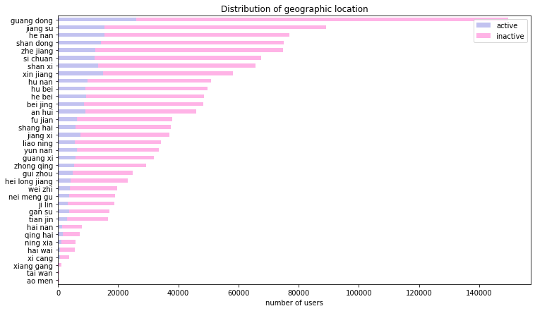

```python
#draw distribution of geographic location of active and inactive users
a = loc_active['province']
b = loc_inactive['province']
c = loc_all['province']
location = pd.DataFrame({'active' : a,'inactive' : b, 'all':c}).sort_values('all')
ax = location[['active','inactive']].plot.barh(stacked=True,color=['#c2c2f0','#ffb3e6'])
plt.xlabel('number of users')
ax.figure.set_size_inches(12,7)

ax.set_title("Distribution of geographic location")
ax.legend(loc='upper right')
```

```python
location = location.reset_index(drop=False)
location.columns = ['province', 'active', 'inactive', 'all']
```

```python
#merge location and gdp
location = location.merge(prov_gdp,how='left',on='province')
location.head()
```

|  | province | active | inactive | all | GDP(billion_yuan) |
| --- | --- | --- | --- | --- | --- |
| 0 | ao men | 51 | 318 | 369 | NaN |
| 1 | tai wan | 65 | 435 | 500 | NaN |
| 2 | xiang gang | 148 | 1007 | 1155 | NaN |
| 3 | xi cang | 723 | 2922 | 3645 | 169.78 |
| 4 | hai wai | 583 | 5068 | 5651 | NaN |

```python
#calculate active rate
location['active_perc'] = location['active']/location['all']
```

```python
print('The average active rate is',location['active_perc'].mean())
print('The proportion of provinces with a higher active rate than the average active rate is', len(location.loc[location['active_perc']>=location['active_perc'].mean()])/len(location))
```

```
The average active rate is 0.18286840778584126
The proportion of provinces with a higher active rate than the average active rate is 0.5428571428571428
```

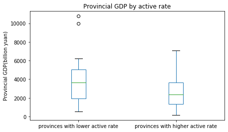

```python
#draw provincial GDP by active rate
a1 = location.loc[location['active_perc']<location['active_perc'].mean()]['GDP(billion_yuan)'].dropna()
b1 = location.loc[location['active_perc']>=location['active_perc'].mean()]['GDP(billion_yuan)'].dropna()
active_rate = pd.DataFrame({'provinces with lower active rate' : a1,'provinces with higher active rate' : b1})

plt.figure(figsize=(7,4))
boxplot = active_rate.boxplot(grid=False)
plt.ylabel('Provincial GDP(billion yuan)')
plt.title('Provincial GDP by active rate',size=12)
```

```python
print('The average GDP in provinces with lower active rate is', a1.mean())
print('The average GDP in provinces with higheer active rate is', b1.mean())
```

```
The average GDP in provinces with lower active rate is 4245.6525
The average GDP in provinces with higheer active rate is 2549.045
```

The average active rate among provinces is about 18% and nearly half of the provinces are with an active rate above the average level. Provinces like Beijing, Shanghai, Guangdong are with lower active rate and provinces with higher active rate includes Xinjiang, Tibet, Qinghai, etc. The above box plot shows that provinces with lower active rate have generally higher level of GDP. The average GDP in provinces with lower and higher active rate are 4245.6525 and 2549.045 respectively.

Above all, we find that users from more developped regions are less likely to be active in general. The intuitive interpretation to this is that, users from more developped regions(provinces with higher GDP level) are more often live a hectic life so that they have less time for leisure. Moreover, these users face more diversified ways for entertainment, therefore it is harder to attract them and keep them addicted to the application. On the contrary, users from less developped regions may have more time and lower quality requirements.

- ### Gender and Age

```python
gender_all = pd.DataFrame(user_demo_prob['gender'].value_counts())
gender_active = pd.DataFrame(user_demo_prob.loc[user_demo_prob['activity']==1]['gender'].value_counts())
gender_inactive = pd.DataFrame(user_demo_prob.loc[user_demo_prob['activity']==0]['gender'].value_counts())
```

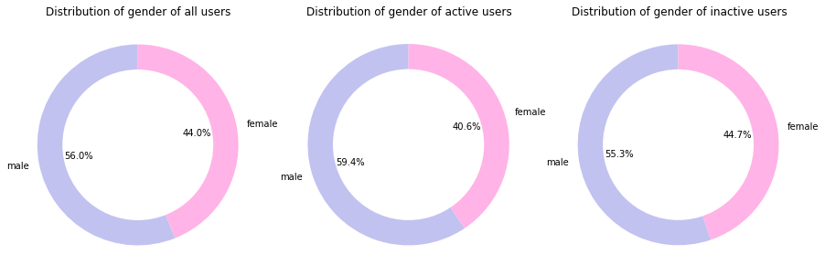

```python
#draw distribution of gender
labels_all = gender_all.index
sizes_all = gender_all['gender']
labels_active = gender_active.index
sizes_active = gender_active['gender']
labels_inactive = gender_inactive.index
sizes_inactive = gender_inactive['gender']
explode = (0, 0)  # only "explode" the 2nd slice (i.e. 'Hogs')

colors = ['#c2c2f0','#ffb3e6']

plt.figure(figsize=(15,5))

plt.subplot(1,3,1)
plt.title('Distribution of gender of all users',size=12)
plt.pie(sizes_all, explode=explode, labels=labels_all, autopct='%1.1f%%',
        shadow=False, startangle=90, colors = colors)
centre_circle = plt.Circle((0,0),0.75,fc='white')
fig = plt.gcf()
fig.gca().add_artist(centre_circle)
plt.axis('equal')  # Equal aspect ratio ensures that pie is drawn as a circle.

plt.subplot(1,3,2)
plt.title('Distribution of gender of active users',size=12)
plt.pie(sizes_active, explode=explode, labels=labels_active, autopct='%1.1f%%',
        shadow=False, startangle=90,colors = colors)
centre_circle = plt.Circle((0,0),0.75,fc='white')
fig = plt.gcf()
fig.gca().add_artist(centre_circle)
plt.axis('equal')  # Equal aspect ratio ensures that pie is drawn as a circle.

plt.subplot(1,3,3)
plt.title('Distribution of gender of inactive users',size=12)
plt.pie(sizes_inactive, explode=explode, labels=labels_inactive, autopct='%1.1f%%',
        shadow=False, startangle=90,colors = colors)
centre_circle = plt.Circle((0,0),0.75,fc='white')
fig = plt.gcf()
fig.gca().add_artist(centre_circle)
plt.axis('equal')  # Equal aspect ratio ensures that pie is drawn as a circle.

plt.show()
```

We can see that male users represents a larger proportion in active users than female users and the percentage of female users in inactive users is higher than that in active users. Hence, we can loosely infer that the application may be more appealing to the male users than to the female users.

```python
a2 = pd.DataFrame(user_demo_prob['age'].value_counts())['age']
b2 = pd.DataFrame(user_demo_prob['age'].loc[user_demo_prob['activity']==1].value_counts())['age']
c2 = pd.DataFrame(user_demo_prob['age'].loc[user_demo_prob['activity']==0].value_counts())['age']
age = pd.DataFrame({'all' : a2,'active' : b2,'inactive':c2})
pd.options.display.float_format = '{:.4f}'.format
```

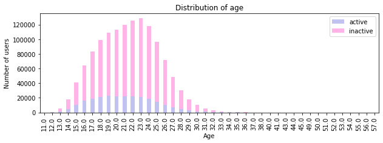

```python
#draw distribution of age of all users
ax = age[['active','inactive']].plot.bar(stacked=True,color=['#c2c2f0','#ffb3e6'])
plt.xlabel('Age')
plt.ylabel('Number of users')
ax.figure.set_size_inches(10,3)

ax.set_title("Distribution of age")
ax.legend(loc='upper right')
```

```python
#get statistics of age
pd.DataFrame({'all':user_demo_prob['age'],'active':user_demo_prob['age'].loc[user_demo_prob['activity']==1],'inactive':user_demo_prob['age'].loc[user_demo_prob['activity']==0]}).describe()
```

|  | all | active | inactive |
| --- | --- | --- | --- |
| count | 1313681.0000 | 245733.0000 | 1067948.0000 |
| mean | 21.4915 | 20.8660 | 21.6354 |
| std | 3.7630 | 3.8326 | 3.7320 |
| min | 11.0000 | 12.0000 | 11.0000 |
| 25% | 19.0000 | 18.0000 | 19.0000 |
| 50% | 22.0000 | 21.0000 | 22.0000 |
| 75% | 24.0000 | 24.0000 | 24.0000 |
| max | 57.0000 | 55.0000 | 57.0000 |

```python
active_age_gender = user_demo_prob.loc[user_demo_prob['activity']==1][['age','gender']]
inactive_age_gender = user_demo_prob.loc[user_demo_prob['activity']==0][['age','gender']]
a3 = active_age_gender.loc[active_age_gender['gender']=='male']['age'].value_counts()
b3 = active_age_gender.loc[active_age_gender['gender']=='female']['age'].value_counts()
a4 = inactive_age_gender.loc[inactive_age_gender['gender']=='male']['age'].value_counts()
b4 = inactive_age_gender.loc[inactive_age_gender['gender']=='female']['age'].value_counts()
age_gender = pd.DataFrame({'active male' : a3,'active female' : b3,'inactive male':a4,'inactive female':b4})
```

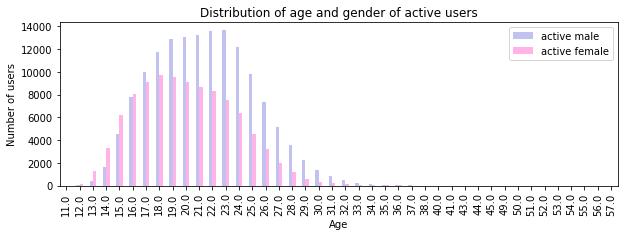

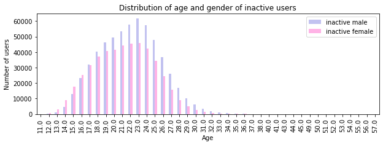

```python
#draw distribution of age and gender
ax1 = age_gender[['active male','active female']].plot.bar(stacked=False,color=['#c2c2f0','#ffb3e6'])
plt.xlabel('Age')
plt.ylabel('Number of users')
ax1.figure.set_size_inches(10,3)

ax1.set_title("Distribution of age and gender of active users")
ax1.legend(loc='upper right')

ax2 = age_gender[['inactive male','inactive female']].plot.bar(stacked=False,color=['#c2c2f0','#ffb3e6'])
plt.xlabel('Age')
plt.ylabel('Number of users')
ax2.figure.set_size_inches(10,3)

ax2.set_title("Distribution of age and gender of inactive users")
ax2.legend(loc='upper right')
```

```python
a5 = active_age_gender.loc[active_age_gender['gender']=='male']['age']
b5 = active_age_gender.loc[active_age_gender['gender']=='female']['age']
a6 = inactive_age_gender.loc[inactive_age_gender['gender']=='male']['age']
b6 = inactive_age_gender.loc[inactive_age_gender['gender']=='female']['age']
age_gender_1 = pd.DataFrame({'active male' : a5,'active female' : b5,'inactive male':a6,'inactive female':b6})
```

```python
##get statistics of age and gender
age_gender_1.describe()
```

|  | active male | active female | inactive male | inactive female |
| --- | --- | --- | --- | --- |
| count | 145979.0000 | 99754.0000 | 590239.0000 | 477709.0000 |
| mean | 21.4360 | 20.0318 | 21.9978 | 21.1877 |
| std | 3.8106 | 3.7099 | 3.7089 | 3.7119 |
| min | 12.0000 | 12.0000 | 11.0000 | 11.0000 |
| 25% | 19.0000 | 17.0000 | 19.0000 | 18.0000 |
| 50% | 21.0000 | 20.0000 | 22.0000 | 21.0000 |
| 75% | 24.0000 | 23.0000 | 25.0000 | 24.0000 |
| max | 55.0000 | 54.0000 | 57.0000 | 57.0000 |

Among the youngest active and inactive users (12-16 years), girls are a majority, though that changes with the age of 17 onwards, where users are predominantly male. Among female users, younger users are more likely to become active, since average age of active female users is smaller than that of inactive female users. No big age difference between active and inactive male cohorts.

### 1.4 User behavior

Having developed an understanding the demographic features of active and inactive users, we then seek to better understand the impact of tenure, defined as the length of their contract, on their level of engagement.

- ### Tenure

```python
tenure = pd.DataFrame(user_demo_prob['registeredMonthCnt'].value_counts()).reset_index(drop=False)
tenure.columns = ['months','user_counts']
tenure = tenure.sort_values('months').reset_index(drop=True)
```

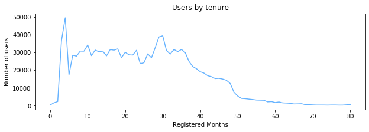

```python
plt.figure(figsize=(10,3))
plt.plot(tenure['months'],tenure['user_counts'],color = '#66b3ff')
plt.xlabel('Registered Months')
plt.ylabel('Number of users')

plt.title('Users by tenure',size=12)

plt.show()
```

```python
tenure['average_click_perc'] = user_demo_prob['click_perc'].groupby(user_demo_prob['registeredMonthCnt']).mean()
```

```python
active1 = user_demo_prob.loc[user_demo_prob['activity']==1]
active_tenure = pd.DataFrame(active1['registeredMonthCnt'].value_counts()).reset_index(drop=False)
active_tenure.columns=['months','active_user_counts']
active_tenure = active_tenure.sort_values('months').reset_index(drop=True)
active_tenure['active_click_perc'] = active1['click_perc'].groupby(active1['registeredMonthCnt']).mean()
inactive1 = user_demo_prob.loc[user_demo_prob['activity']==0]
inactive_tenure = pd.DataFrame(inactive1['registeredMonthCnt'].value_counts()).reset_index(drop=False)
inactive_tenure.columns=['months','inactive_user_counts']
inactive_tenure = inactive_tenure.sort_values('months').reset_index(drop=True)
inactive_tenure['inactive_click_perc'] = inactive1['click_perc'].groupby(inactive1['registeredMonthCnt']).mean()
```

```python
tenure['active_user_counts']=active_tenure['active_user_counts']
tenure['inactive_user_counts']=inactive_tenure['inactive_user_counts']
tenure['active_perc']=tenure['active_user_counts']/tenure['inactive_user_counts']
tenure['active_click_perc']=active_tenure['active_click_perc']
tenure['inactive_click_perc']=inactive_tenure['inactive_click_perc']
```

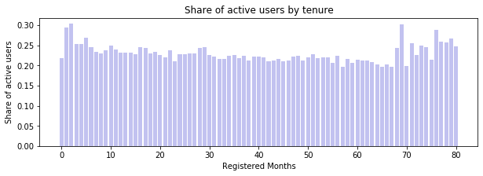

```python
plt.figure(figsize=(10,3))
plt.bar(tenure['months'],tenure['active_perc'],color = '#c2c2f0')
plt.xlabel('Registered Months')
plt.ylabel('Share of active users')
#plt.ylim(0.015,0.035)
#z = np.polyfit(tenure['months'], tenure['average_click_perc'], 1)
#p = np.poly1d(z)
#plt.plot(tenure['months'], p(tenure['months']),color = '#66b3ff')
plt.title('Share of active users by tenure',size=12)

plt.show()
```

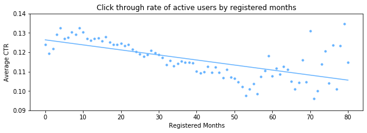

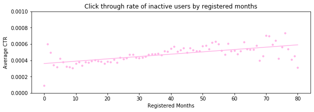

```python
plt.figure(figsize=(10,3))
plt.scatter(tenure['months'],tenure['active_click_perc'],color = '#66b3ff',s=10)
plt.xlabel('Registered Months')
plt.ylabel('Average CTR')
plt.ylim(0.09,0.14)
z1 = np.polyfit(tenure['months'], tenure['active_click_perc'], 1)
p1 = np.poly1d(z1)
plt.plot(tenure['months'], p1(tenure['months']),color = '#66b3ff')
plt.title('Click through rate of active users by registered months',size=12)

plt.figure(figsize=(10,3))
plt.scatter(tenure['months'],tenure['inactive_click_perc'],color = '#ffb3e6',s=10)
plt.xlabel('Registered Months')
plt.ylabel('Average CTR')
plt.ylim(0,0.001)
z = np.polyfit(tenure['months'], tenure['inactive_click_perc'], 1)
p = np.poly1d(z)
plt.plot(tenure['months'], p(tenure['months']),color = '#ffb3e6')
plt.title('Click through rate of inactive users by registered months',size=12)


plt.show()
```

```python
newusers = tenure.loc[tenure['months']<=6]['average_click_perc'].mean()
olduswers = tenure.loc[tenure['months']>6]['average_click_perc'].mean()
(newusers - olduswers)/olduswers
```

```
0.21753848312084692
```

- ### Content

In addition to the analysis of user tenure, we look at users' activity patterns in comparison with the less engaged users based on impression dataset. We also review the behavior of the new users (tenure <= 6 months), as NCM may be particularly interested in being able to catch any early signs of high engagement.

```python
#join impression table with click probablity table
impression_mlog_user = impression.merge(click_prob,how='inner',on='userId')
```

```python
#join impression table with mlog_demo table
impression_mlog_user = impression_mlog_user.merge(mlog_demo,how='inner',on='mlogId')
```

```python
#join impression table with click probablity table
impression_mlog_user = impression_mlog_user.merge(user_demo[['userId','registeredMonthCnt']],how='inner',on='userId')
```

```python
#get new users
impression_mlog_newuser = impression_mlog_user.loc[impression_mlog_user['registeredMonthCnt']<=6]
```

```python
#get active/inactive users
impression_mlog_active_user = impression_mlog_user.loc[impression_mlog_user['activity']==1]
impression_mlog_inactive_user = impression_mlog_user.loc[impression_mlog_user['activity']==0]
impression_mlog_active_newuser = impression_mlog_newuser.loc[impression_mlog_newuser['activity']==1]
impression_mlog_inactive_newuser = impression_mlog_newuser.loc[impression_mlog_newuser['activity']==0]
```

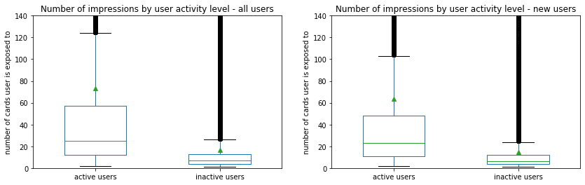

```python
#draw number of impressions by user activity level
a7 = impression_mlog_active_user['userId'].value_counts()
b7 = impression_mlog_inactive_user['userId'].value_counts()
impr_activity_alluser = pd.DataFrame({'active users' : a7,'inactive users' : b7})
a8 = impression_mlog_active_newuser['userId'].value_counts()
b8 = impression_mlog_inactive_newuser['userId'].value_counts()
impr_activity_newuser = pd.DataFrame({'active users' : a8,'inactive users' : b8})

plt.figure(figsize=(14,4))
plt.subplot(121)
#plt.figure(figsize=(5,4))
boxplot = impr_activity_alluser.boxplot(grid=False,widths=0.5,showmeans=True)
plt.ylim(0,140)
plt.ylabel('number of cards user is exposed to')
plt.title('Number of impressions by user activity level - all users',size=12)

plt.subplot(122)
#plt.figure(figsize=(5,4))
boxplot = impr_activity_newuser.boxplot(grid=False,widths=0.5,showmeans=True)
plt.ylim(0,140)
plt.ylabel('number of cards user is exposed to')
plt.title('Number of impressions by user activity level - new users',size=12)

plt.show()
```

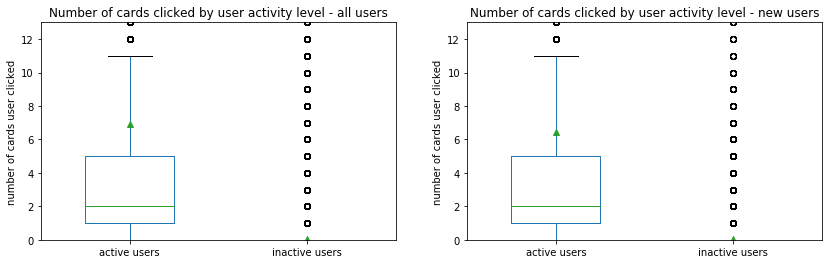

```python
#draw number of cards clicked by user activity level
a9 = impression_mlog_active_user['isClick'].groupby(impression_mlog_active_user['userId']).sum()
b9 = impression_mlog_inactive_user['isClick'].groupby(impression_mlog_inactive_user['userId']).sum()
impr_click_alluser = pd.DataFrame({'active users' : a9,'inactive users' : b9})
a10 = impression_mlog_active_newuser['isClick'].groupby(impression_mlog_active_newuser['userId']).sum()
b10 = impression_mlog_inactive_newuser['isClick'].groupby(impression_mlog_inactive_newuser['userId']).sum()
impr_click_newuser = pd.DataFrame({'active users' : a10,'inactive users' : b10})

plt.figure(figsize=(14,4))

plt.subplot(121)
#plt.figure(figsize=(5,4))
boxplot = impr_click_alluser.boxplot(grid=False,widths=0.5,showmeans=True)
plt.ylim(0,13)
plt.ylabel('number of cards user clicked')
plt.title('Number of cards clicked by user activity level - all users',size=12)

plt.subplot(122)
#plt.figure(figsize=(5,4))
boxplot = impr_click_newuser.boxplot(grid=False,widths=0.5,showmeans=True)
plt.ylim(0,13)
plt.ylabel('number of cards user clicked')
plt.title('Number of cards clicked by user activity level - new users',size=12)

plt.show()
```

```python
a9.append(b9).describe()
```

```
count   2085111.0000
mean          1.3762
std          10.1131
min           0.0000
25%           0.0000
50%           0.0000
75%           0.0000
max        2079.0000
Name: isClick, dtype: float64
```

```python
a10.append(b10).describe()
```

```
count   328877.0000
mean         1.3402
std         10.5547
min          0.0000
25%          0.0000
50%          0.0000
75%          0.0000
max       1300.0000
Name: isClick, dtype: float64
```

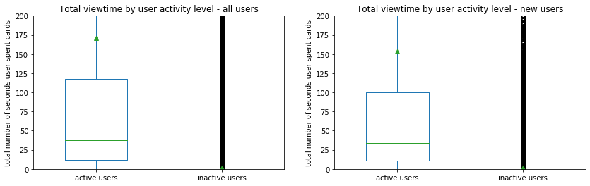

```python
#draw total viewtime by user activity level
a11 = impression_mlog_active_user['mlogViewTime'].groupby(impression_mlog_active_user['userId']).sum()
b11 = impression_mlog_inactive_user['mlogViewTime'].groupby(impression_mlog_inactive_user['userId']).sum()
impr_viewtime_alluser = pd.DataFrame({'active users' : a11,'inactive users' : b11})
a12 = impression_mlog_active_newuser['mlogViewTime'].groupby(impression_mlog_active_newuser['userId']).sum()
b12 = impression_mlog_inactive_newuser['mlogViewTime'].groupby(impression_mlog_inactive_newuser['userId']).sum()
impr_viewtime_newuser = pd.DataFrame({'active users' : a12,'inactive users' : b12})

plt.figure(figsize=(14,4))
plt.subplot(121)
#plt.figure(figsize=(5,4))
boxplot = impr_viewtime_alluser.boxplot(grid=False,widths=0.5,showmeans=True)
plt.ylim(0,200)
plt.ylabel('total number of seconds user spent cards')
plt.title('Total viewtime by user activity level - all users',size=12)

plt.subplot(122)
#plt.figure(figsize=(5,4))
boxplot = impr_viewtime_newuser.boxplot(grid=False,widths=0.5,showmeans=True)
plt.ylim(0,200)
plt.ylabel('total number of seconds user spent cards')
plt.title('Total viewtime by user activity level - new users',size=12)

plt.show()
```

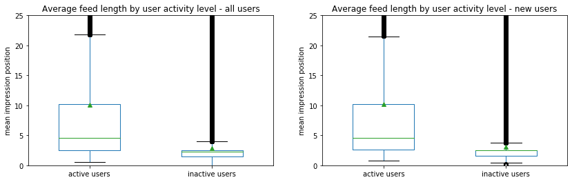

```python
#draw average feed length by user activity level
a13 = impression_mlog_active_user['impressPosition'].groupby(impression_mlog_active_user['userId']).mean()
b13 = impression_mlog_inactive_user['impressPosition'].groupby(impression_mlog_inactive_user['userId']).mean()
impr_position_alluser = pd.DataFrame({'active users' : a13,'inactive users' : b13})
a14 = impression_mlog_active_newuser['impressPosition'].groupby(impression_mlog_active_newuser['userId']).mean()
b14 = impression_mlog_inactive_newuser['impressPosition'].groupby(impression_mlog_inactive_newuser['userId']).mean()
impr_position_newuser = pd.DataFrame({'active users' : a14,'inactive users' : b14})

plt.figure(figsize=(14,4))
plt.subplot(121)
#plt.figure(figsize=(5,4))
boxplot = impr_position_alluser.boxplot(grid=False,widths=0.5,showmeans=True)
plt.ylim(0,25)
plt.ylabel('mean impression position')
plt.title('Average feed length by user activity level - all users',size=12)

plt.subplot(122)
#plt.figure(figsize=(5,4))
boxplot = impr_position_newuser.boxplot(grid=False,widths=0.5,showmeans=True)
plt.ylim(0,25)
plt.ylabel('mean impression position')
plt.title('Average feed length by user activity level - new users',size=12)

plt.show()
```

```python
follow = user_demo_prob[['userId','followCnt','registeredMonthCnt','activity']].drop_duplicates()
```

```python
follow_newuser = follow.loc[follow['registeredMonthCnt']<=6]
```

```python
follow_active_user = follow.loc[follow['activity']==1]
follow_inactive_user = follow.loc[follow['activity']==0]
follow_active_newuser = follow_newuser.loc[follow_newuser['activity']==1]
follow_inactive_newuser = follow_newuser.loc[follow_newuser['activity']==0]
```

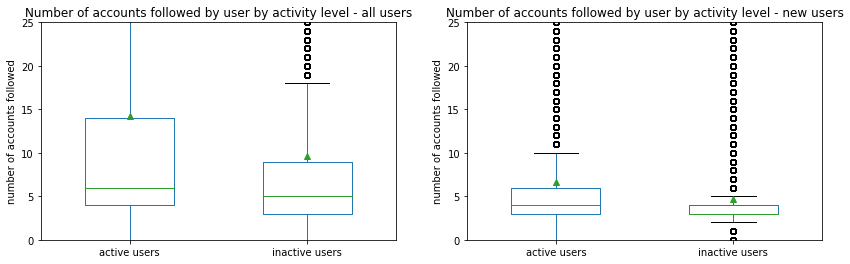

```python
#draw average feed length by user activity level
a15 = follow_active_user['followCnt']
b15 = follow_inactive_user['followCnt']
followcnt_alluser = pd.DataFrame({'active users' : a15,'inactive users' : b15})
a16 = follow_active_newuser['followCnt']
b16 = follow_inactive_newuser['followCnt']
followcnt_newuser = pd.DataFrame({'active users' : a16,'inactive users' : b16})
plt.figure(figsize=(14,4))
plt.subplot(121)
#plt.figure(figsize=(5,4))
boxplot = followcnt_alluser.boxplot(grid=False,widths=0.5,showmeans=True)
plt.ylim(0,25)
plt.ylabel('number of accounts followed')
plt.title('Number of accounts followed by user by activity level - all users',size=12)

plt.subplot(122)
#plt.figure(figsize=(5,4))
boxplot = followcnt_newuser.boxplot(grid=False,widths=0.5,showmeans=True)
plt.ylim(0,25)
plt.ylabel('number of accounts followed')
plt.title('Number of accounts followed by user by activity level - new users',size=12)

plt.show()
```

```python
a13.append(b13).describe()
```

```
count   2085111.0000
mean          4.2666
std          11.3598
min           0.0000
25%           1.5000
50%           2.5000
75%           2.7250
max        5289.6711
Name: impressPosition, dtype: float64
```

```python
a14.append(b14).describe()
```

```
count   328877.0000
mean         4.5736
std         11.6300
min          0.0000
25%          2.0000
50%          2.5000
75%          3.0000
max       1239.9972
Name: impressPosition, dtype: float64
```

The active users are exposed to a significantly higher volume of recommendations, and their number of clicks, seconds of viewtime and average feed length are also much larger than those of the inactive users. That indicates that users of active class tend to scroll far down their feed and spend more time on the application, but the inactive users seem to return to the application less often without actively engaging with the content.

If we look at the number of clicks and the length of feed of all users and new users at the same time, we can see that the average number of clicks for new users is smaller than that of all users, while the average length of feed of new users is greater than that of all users. The intuitive interpretation to this is that new users with less personal information available is less likely to get accurate recomendations on top of their feed and thus scroll down in search of interesting content or leave the tab without clicking, while others who get the right recommendations on top of their feed click on the videos more often.

We are also interested in the preference of users among cards of various content. By aggregating the impressions and clicks recorded in November 2019 by user and content ID we can gauge the level of diversity of recommendations and preferences on the platform.

```python
impression_mlog_user.columns
```

```
Index(['detailMlogInfoList', 'dt', 'impressPosition', 'impressTime', 'isClick',
       'isComment', 'isIntoPersonalHomepage', 'isShare', 'isViewComment',
       'isLike', 'mlogId', 'mlogViewTime', 'userId', 'date', 'hour',
       'TotalClick', 'TotalMlog', 'click_perc', 'activity', 'songId',
       'artistId', 'creatorId', 'publishTime', 'type', 'contentId', 'talkId',
       'registeredMonthCnt'],
      dtype='object')
```

```python
impression_mlog_newuser.columns
```

```
Index(['detailMlogInfoList', 'dt', 'impressPosition', 'impressTime', 'isClick',
       'isComment', 'isIntoPersonalHomepage', 'isShare', 'isViewComment',
       'isLike', 'mlogId', 'mlogViewTime', 'userId', 'date', 'hour',
       'TotalClick', 'TotalMlog', 'click_perc', 'activity', 'songId',
       'artistId', 'creatorId', 'publishTime', 'type', 'contentId', 'talkId',
       'registeredMonthCnt'],
      dtype='object')
```

```python
#calculate number of impressions of each contentID that each user is exposed to
content_user = impression_mlog_user.dropna()[['contentId','userId']]
content_user = pd.DataFrame(content_user.groupby(['userId', 'contentId']).size()).reset_index(drop=False)
content_user.columns = ['userId','contentId','impr_counts']
```

```python
#calculate number of impressions of each contentID that each new user is exposed to
content_newuser = impression_mlog_newuser.dropna()[['contentId','userId']]
content_newuser = pd.DataFrame(content_newuser.groupby(['userId', 'contentId']).size()).reset_index(drop=False)
content_newuser.columns = ['userId','contentId','impr_counts']
```

```python
#calculate the total number of impressions each (new)user is exposed to
total_impr_user = pd.DataFrame(impression_mlog_user['userId'].value_counts()).reset_index(drop=False)
total_impr_user.columns=['userId','total_impr']
total_impr_newuser = pd.DataFrame(impression_mlog_newuser['userId'].value_counts()).reset_index(drop=False)
total_impr_newuser.columns=['userId','total_impr']
```

```python
#calculate share of exposure for all users
content_user = content_user.merge(total_impr_user,how='inner',on='userId')
content_user['exp_share']=content_user['impr_counts']/content_user['total_impr']
```

```python
#calculate share of exposure for new users
content_newuser = content_newuser.merge(total_impr_newuser,how='inner',on='userId')
content_newuser['exp_share']=content_newuser['impr_counts']/content_newuser['total_impr']
```

```python
#change to pivot table
exposure_pivot = content_user.pivot_table(index='userId', columns='contentId', values = 'exp_share')
exposure_pivot_new = content_newuser.pivot_table(index='userId', columns='contentId', values = 'exp_share')
```

```python
#get all contentID
total_column_list = impression_mlog_user['contentId'].dropna().unique()
alluser_column_list = list(set(total_column_list) - set(exposure_pivot))
newuser_column_list = list(set(total_column_list) - set(exposure_pivot_new))
```

```python
#ensure each pivot table contains all the contentID
for x in alluser_column_list:
    exposure_pivot[x]=0
for y in newuser_column_list:
    exposure_pivot_new[y]=0
```

```python
#sort pivot table by contentID
exposure_pivot = exposure_pivot.sort_index(axis=1)
exposure_pivot_new = exposure_pivot_new.sort_index(axis=1)
```

```python
exposure_pivot.head()
```

| contentId userId | 1000,1004,3007 | 1000,1004,3008 | 1000,1005,1014 | 1000,1006,3010 | 1001,2001,3018 | 1001,2002,2010 | 1003,3000,1026 | 1003,3000,1027 | 1003,3001,1038 | 1003,3002,3020 | ... | 5004,5026,5143 | 5004,5027,5145 | 5004,5027,5146 | 5004,5027,5147 | 5004,5027,5148 | 5004,5027,5150 | 5004,5027,5151 | 5004,5028,5152 | 5004,5028,5153 | 5004,5028,5154 |
| --- | --- | --- | --- | --- | --- | --- | --- | --- | --- | --- | --- | --- | --- | --- | --- | --- | --- | --- | --- | --- | --- |
| GCGCGCHCKCGCHC | 0 | 0 | 0 | nan | 0 | nan | nan | nan | nan | 0 | ... | nan | nan | nan | nan | nan | nan | nan | nan | nan | nan |
| GCGCGCHCPCNCPCKC | 0 | 0 | 0 | nan | 0 | nan | nan | nan | nan | 0 | ... | nan | nan | nan | nan | nan | nan | nan | nan | nan | nan |
| GCGCGCICGCOCKCIC | 0 | 0 | 0 | nan | 0 | nan | nan | nan | nan | 0 | ... | nan | nan | nan | nan | nan | nan | nan | nan | nan | nan |
| GCGCGCICKCLCMCGC | 0 | 0 | 0 | nan | 0 | nan | nan | nan | nan | 0 | ... | nan | nan | nan | nan | nan | nan | nan | nan | nan | nan |
| GCGCGCJCMCJCKCIC | 0 | 0 | 0 | nan | 0 | nan | nan | nan | nan | 0 | ... | nan | nan | nan | nan | nan | nan | nan | nan | nan | nan |

5 rows × 122 columns

```python
exposure_pivot_new.head()
```

| contentId userId | 1000,1004,3007 | 1000,1004,3008 | 1000,1005,1014 | 1000,1006,3010 | 1001,2001,3018 | 1001,2002,2010 | 1003,3000,1026 | 1003,3000,1027 | 1003,3001,1038 | 1003,3002,3020 | ... | 5004,5026,5143 | 5004,5027,5145 | 5004,5027,5146 | 5004,5027,5147 | 5004,5027,5148 | 5004,5027,5150 | 5004,5027,5151 | 5004,5028,5152 | 5004,5028,5153 | 5004,5028,5154 |
| --- | --- | --- | --- | --- | --- | --- | --- | --- | --- | --- | --- | --- | --- | --- | --- | --- | --- | --- | --- | --- | --- |
| GCICMCOCPCNCMCLC | 0 | 0 | 0 | 0 | 0 | 0 | nan | nan | 0 | 0 | ... | nan | nan | nan | nan | nan | nan | nan | nan | nan | nan |
| GCICMCOCPCPCHCNC | 0 | 0 | 0 | 0 | 0 | 0 | nan | nan | 0 | 0 | ... | nan | nan | nan | nan | nan | nan | nan | nan | nan | nan |
| ICKCKCGCHCGCGCICKC | 0 | 0 | 0 | 0 | 0 | 0 | nan | nan | 0 | 0 | ... | nan | nan | nan | nan | nan | nan | nan | nan | nan | nan |
| ICKCMCICICICMCLCIC | 0 | 0 | 0 | 0 | 0 | 0 | nan | nan | 0 | 0 | ... | nan | nan | nan | 0.0333 | nan | nan | nan | nan | nan | nan |
| ICMCICNCMCGCHCPCNC | 0 | 0 | 0 | 0 | 0 | 0 | nan | nan | 0 | 0 | ... | nan | nan | nan | nan | nan | nan | nan | nan | nan | nan |

5 rows × 122 columns

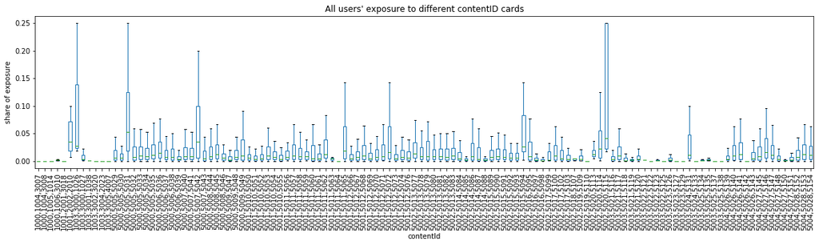

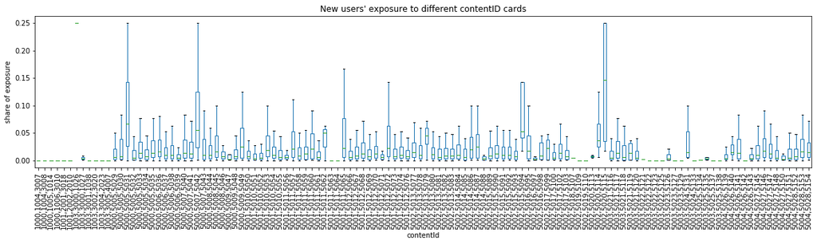

```python
#draw users' exposure to different contentID
plt.figure(figsize=(20,4))
boxplot = exposure_pivot.boxplot(grid=False,showfliers=False)
plt.xticks(rotation=90)
plt.xlabel('contentId')
plt.ylabel('share of exposure')
plt.title("All users' exposure to different contentID cards",size=12)
plt.show()

plt.figure(figsize=(20,4))
boxplot1 = exposure_pivot_new.boxplot(grid=False,showfliers=False)
plt.xticks(rotation=90)
plt.xlabel('contentId')
plt.ylabel('share of exposure')
plt.title("New users' exposure to different contentID cards",size=12)

plt.show()
```

```python
#calculate number of clicks for each contentID of each user
content_user_click = impression_mlog_user.dropna()[['contentId','userId','isClick']]
content_user_click = content_user_click.groupby(['userId', 'contentId']).agg({'isClick': 'sum'}).reset_index(drop=False)
content_user_click.columns = ['userId','contentId','click_counts']
```

```python
#calculate number of clicks for each contentID of each new user
content_newuser_click = impression_mlog_newuser.dropna()[['contentId','userId','isClick']]
content_newuser_click = content_newuser_click.groupby(['userId', 'contentId']).agg({'isClick': 'sum'}).reset_index(drop=False)
content_newuser_click.columns = ['userId','contentId','click_counts']
```

```python
#calculate the share of clicks of all users
content_user_click = content_user_click.merge(total_impr_user,how='inner',on='userId')
content_user_click['click_perc'] = content_user_click['click_counts']/content_user_click['total_impr']
```

```python
#calculate the share of clicks of new users
content_newuser_click = content_newuser_click.merge(total_impr_user,how='inner',on='userId')
content_newuser_click['click_perc'] = content_newuser_click['click_counts']/content_newuser_click['total_impr']
```

```python
#change to pivot table
click_pivot = content_user_click.pivot_table(index='userId', columns='contentId', values = 'click_perc')
click_pivot_new = content_newuser_click.pivot_table(index='userId', columns='contentId', values = 'click_perc')
```

```python
#ensure pivot table contains all the contentID
for x in alluser_column_list:
    click_pivot[x]=0
for y in newuser_column_list:
    click_pivot_new[y]=0
```

```python
#sort value by contentID
click_pivot = click_pivot.sort_index(axis=1)
click_pivot_new = click_pivot_new.sort_index(axis=1)
```

[figure not shown]

[figure not shown]

```python
#draw users' clicks on different contentID cards
plt.figure(figsize=(20,4))
boxplot = click_pivot.boxplot(grid=False,showfliers=False)
plt.xticks(rotation=90)
plt.xlabel('contentId')
plt.ylabel('share of clicks')
plt.title("All users' clicks on different contentID cards",size=12)
plt.show()

plt.figure(figsize=(20,4))
boxplot = click_pivot_new.boxplot(grid=False,showfliers=False)
plt.xticks(rotation=90)
plt.xlabel('contentId')
plt.ylabel('share of clicks')
plt.title("New users' clicks on different contentID cards",size=12)
plt.show()
```

The plots above highlight the popularity patterns. The boxplots show the share of clicks, that cards of a particular content ID received during the month across all users, calculating by the percentage of clicks to total impressions a user is exposed to. The share of clicks for the majority of content types is below 5%, whereas around 4 visible bars enjoyed a share of clicks that reached over 10%. The content that appeals to new users is different from that of all users. For example, contentId '5002,5015,5094' is more popular among new users, while no clicks from new users for contentId '1001,2002,2010' and '1003,3000,1026' which enjoy popularity among all users.

In conclusion, the main findings we get from the data exploration are:

- Users from less developped regions are more likely to be active in general.
- The application may be more appealing to the male users.
- The user population, especially the active user population, for the application is young.
- New users with less than 6 months of tenure and longtime users with over 60 months of tenure are more likely to be active.
- Volume of recommendations and average feed length are larger for active users.

Based on these findings, we next try some machine learning models to predict users' activity intensity level with user demographic information and early behavoirs.